# BU Biostats Faculty Collaboration Network

Dan Posner

October 27, 2016

## Package loading

```r
ipak <- function(pkg){
  new.pkg <- pkg[!(pkg %in% installed.packages()[, "Package"])]
  if (length(new.pkg))
    install.packages(new.pkg, dependencies = TRUE)
  sapply(pkg, require, character.only = TRUE)
}

packages <- c("data.table","statnet", "ndtv",
              "scatterplot3d","htmlwidgets","tsna")
ipak(packages)
```

## Data input

We’ll read in the dataset I made of pubmed articles with at least 2 biostat faculty co-authors.  
The data matrix is Article X Faculty, with two header columns (article name and year).

```r
# Read in dataset
DT <- fread('data/edge_dat.csv', header=T)
head(DT)
```

```
##       title year adrienne anita bob chingti david gheorghe gina howard
## 1: 11756058 2002        1     0   0       0     0        0    0      0
## 2: 11824954 2002        1     0   0       0     0        0    0      0
## 3: 12105290 2002        1     0   0       0     0        0    0      0
## 4: 12403660 2002        1     0   0       0     0        0    0      0
## 5: 12456912 2002        0     0   0       0     0        0    0      1
## 6: 12520555 2003        0     0   0       0     0        0    0      0
##    jacqui janice joe josee kathy kerrie lisa marty mike paola serkalem tim
## 1:      0      0   0     0     0      0    0     0    0     0        1   0
## 2:      0      0   0     0     0      0    0     0    0     0        1   0
## 3:      0      0   0     0     0      0    0     1    0     0        0   0
## 4:      0      0   0     0     0      0    0     0    0     0        1   0
## 5:      0      0   0     0     0      0    0     0    0     0        0   1
## 6:      0      0   1     0     0      0    1     0    0     0        0   0
```

```r
# Remove article title
DT <- DT[,title:=NULL]
```

## Create Adjacency Matrices for each year

```r
# Yearly dataset of shared articles
DTlist <- list()
# List of weighted adjacency matrices for each year
Adjlist <- list()
# List of unweighted adjacency matrices for each year
unweighted <- list()

for (i in 1:length(unique(DT$year))) {
  # Subset data.table by year
  DTlist[[i]] = DT[year==unique(DT$year)[i]]
  # remove year column
  DTlist[[i]][,year:=NULL]

  # Create Adjacency matrix
  #  i.e. we want entries in this matrix to be
  #  dot products of two faculty's authorship
  Adjlist[[i]] = as.matrix(t(DTlist[[i]])) %*%
                 as.matrix(DTlist[[i]])

  # Create unweighted adjacency matrix
  unweighted[[i]] = Adjlist[[i]]
  # Set edge weights > 1 to 1
  unweighted[[i]][unweighted[[i]]>1] = 1
}
```

## Creating a dynamic (i.e. temporal) co-authorship network

First we create one network per year.

```r
#   One network per time point (year)
netlist <- lapply(unweighted, function(x)
            as.network(x, directed = F))
```

Then we create a dynamic network from the list of static networks

```r
# Create dynamic network from list of static nets
minyear = min(DT$year) # starts in 2002
maxyear = max(DT$year) # ends in 2016
tnet <- networkDynamic(network.list=netlist,
            onsets=(minyear-1):(maxyear-1),
            termini=minyear:maxyear,
            create.TEAs=T) # add vertex names
```

```
## Dynamic attributes (TEAs) will be created for the following attributes of the networks on network.list:
## Argument base.net not specified, using first element of network.list instead
## Created net.obs.period to describe network
##  Network observation period info:
##   Number of observation spells: 15
##   Maximal time range observed: 2001 until 2016
##   Temporal mode: continuous
##   Time unit: unknown
##   Suggested time increment: NA
```

## Plots and animations of network changes over time

```r
compute.animation(tnet)
```

```
## slice parameters:
##   start:2001
##   end:2016
##   interval:1
##   aggregate.dur:1
##   rule:latest
```

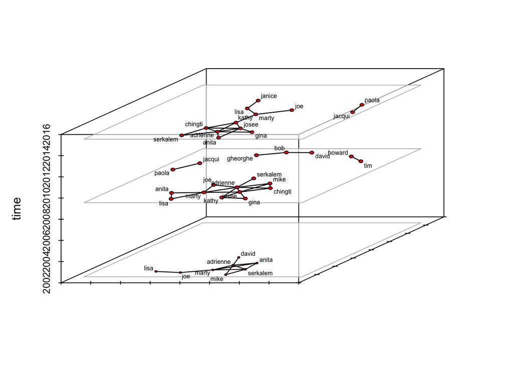

```r
# Time prism projection plot (set displayed slices with at=times)
timePrism(tnet,at=c(2002,2009,2015),
          displaylabels=TRUE,planes = TRUE,
          label.cex=0.5, angle=35,
          displayisolates=F)
```

# Filmstrip plot

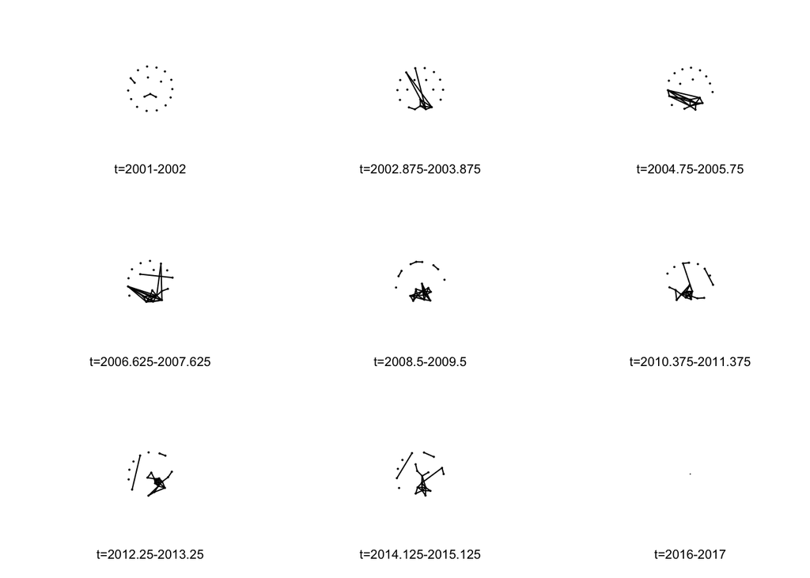

```r
filmstrip(tnet,displaylabels=FALSE)
```

# Network changes over time

```r
render.d3movie(tnet,output.mode = 'htmlWidget', displaylabels=T)
```

[output not shown]

[output not shown]

[output not shown]

[output not shown]

[output not shown]

[output not shown]

[output not shown]

[output not shown]

[output not shown]

[output not shown]

[output not shown]

[output not shown]

[output not shown]

[output not shown]

[output not shown]

[output not shown]

```
## loading ndtv-d3 animation widget...
```

[interactive chart not shown]

# Timeline

If we want to focus solely on the relative durations of collaborations, we can view the dynamics as a timeline by plotting the active spells of edges and vertices. This plot hides network structure and connectivity.

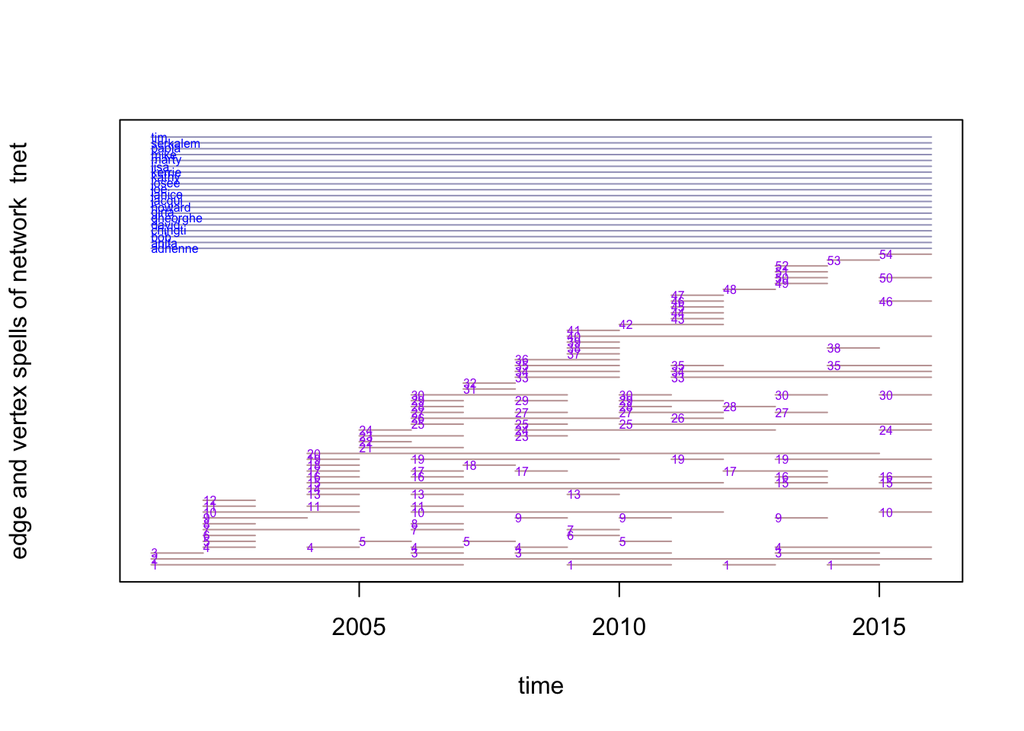

```r
timeline(tnet, displaylabels=T)
```

# Proximity timeline

In this view vertices are positioned vertically by their geodesic distance proximity. This means that changes in network structure deflect the vertices’ lines into new positions, attempting to keep closely-tied vertices as neighbors. The edges are not shown at all in this view.

```r
proximity.timeline(tnet,default.dist=6,
          mode='sammon',labels.at=2009,vertex.cex=4)
```

```
## collapsing slice networks ...
```

```
## computing vertex positions using 1D sammon layout ...
```

[output not shown]

[output not shown]

[output not shown]

[output not shown]

[output not shown]

[output not shown]

[output not shown]

[output not shown]

[output not shown]

[output not shown]

[output not shown]

[output not shown]

[output not shown]

[output not shown]

[output not shown]

```
## rendering splines for each vertex ...
```

[figure not shown]

# Data format of a dynamic network

Have any faculty published together for at least 5 consecutive years?

```r
dat=as.data.frame(tnet)
head(dat)
```

```
##   onset terminus tail head onset.censored terminus.censored duration
## 1  2001     2007    1   16          FALSE             FALSE        6
## 2  2009     2011    1   16          FALSE             FALSE        2
## 3  2012     2013    1   16          FALSE             FALSE        1
## 4  2014     2015    1   16          FALSE             FALSE        1
## 5  2001     2016    1   19          FALSE             FALSE       15
## 6  2001     2002    8   20          FALSE             FALSE        1
##   edge.id
## 1       1
## 2       1
## 3       1
## 4       1
## 5       2
## 6       3
```

```r
dat[dat$duration>=5,]
```

```
##    onset terminus tail head onset.censored terminus.censored duration
## 1   2001     2007    1   16          FALSE             FALSE        6
## 5   2001     2016    1   19          FALSE             FALSE       15
## 31  2006     2012   11   16          FALSE             FALSE        6
## 40  2004     2016    1   12          FALSE             FALSE       12
## 41  2004     2012    1   13          FALSE             FALSE        8
## 58  2004     2015   12   16          FALSE             FALSE       11
## 64  2008     2013   15   16          FALSE             FALSE        5
## 68  2010     2016    1    7          FALSE             FALSE        6
## 88  2011     2016    1    4          FALSE             FALSE        5
## 90  2011     2016    4   12          FALSE             FALSE        5
## 99  2009     2016    9   18          FALSE             FALSE        7
##    edge.id
## 1        1
## 5        2
## 31      10
## 40      14
## 41      15
## 58      20
## 64      24
## 68      25
## 88      33
## 90      34
## 99      40
```

## Calculate some basic network statistics

How many edges form at each time step for the collaboration network? Conveniently, the values are returned as a time series, plot already knows how to handle them.

```r
tEdgeFormation(tnet)
```

```
## Time Series:
## Start = 2001
## End = 2016
## Frequency = 1
##  [1]  3  9  0 10  5 16  4 13  9  8 10  4 12  4  8  0
```

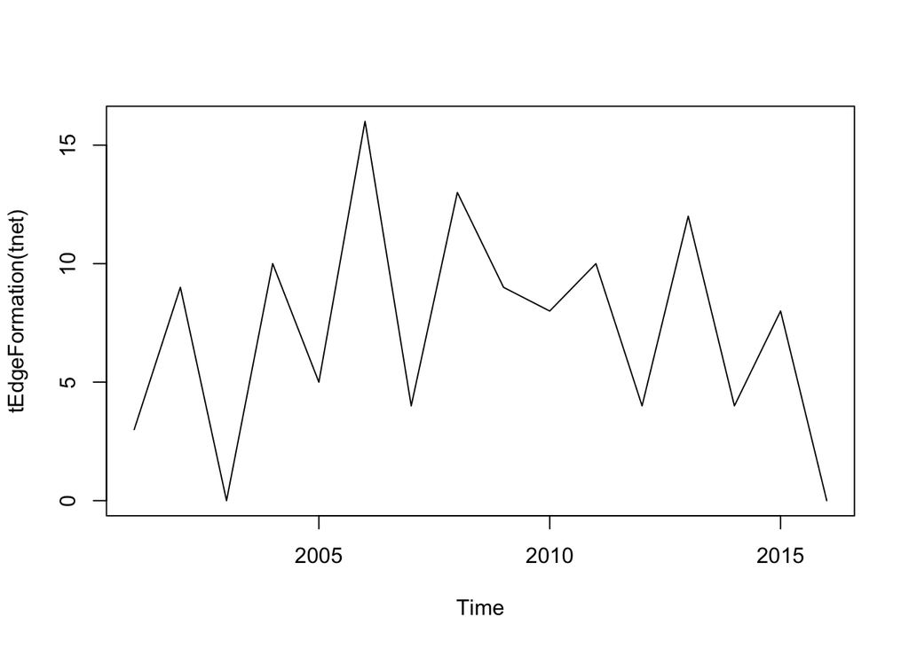

```r
plot(tEdgeFormation(tnet))
```

## Transitivity over time (artificial since didn’t use hyperedges)

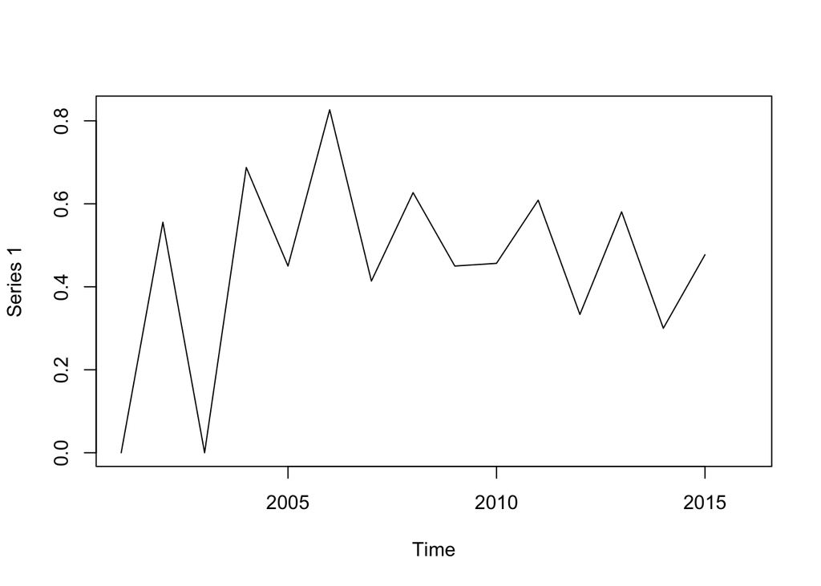

```r
plot(tSnaStats(tnet, 'gtrans'))
```

## Mean degree over time

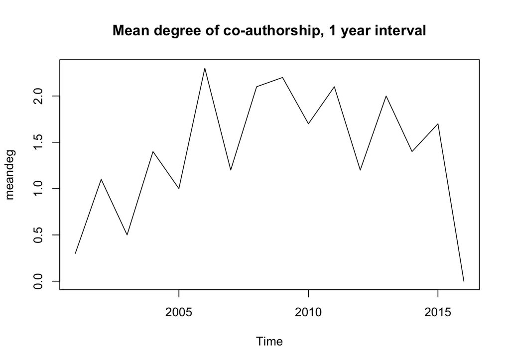

```r
plot(tErgmStats(tnet,'meandeg'),
     main='Mean degree of co-authorship, 1 year interval')
```

## Co-authorship duration from 2002-2016

```r
summary( edgeDuration(tnet) )
```

```
##    Min. 1st Qu.  Median    Mean 3rd Qu.    Max.
##   1.000   1.000   3.000   4.111   6.750  15.000
```

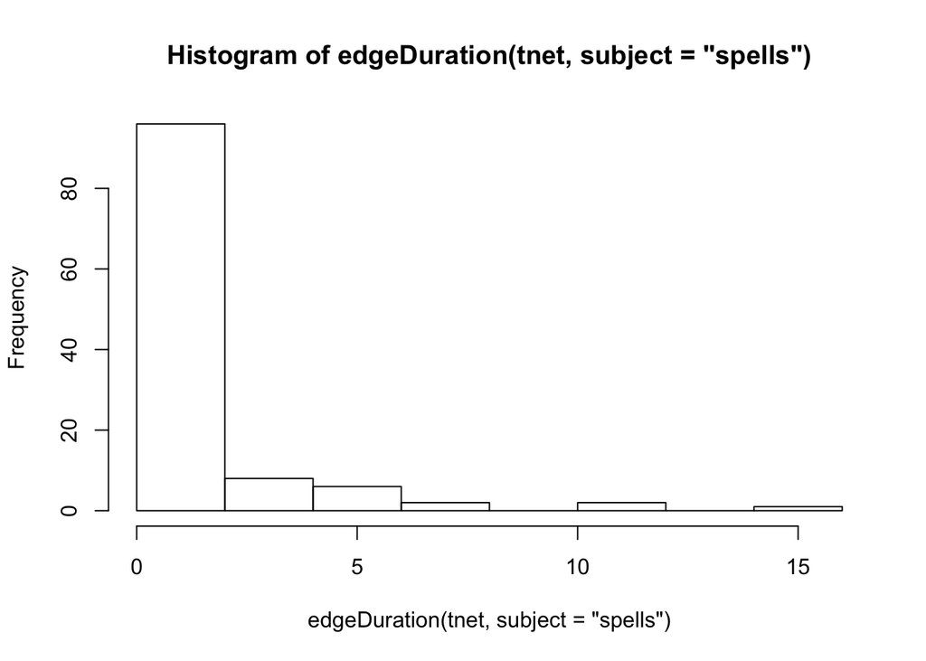

```r
hist(edgeDuration(tnet, subject='spells'))
```

## Co-authorship duration in two 7-year periods: 2003-2009 vs 2010-2016

```r
summary( edgeDuration(tnet,start=2003,end=2009))
```

```
##    Min. 1st Qu.  Median    Mean 3rd Qu.    Max.
##    1.00    1.25    2.00    2.50    3.00    6.00
```

```r
summary( edgeDuration(tnet,start=2010,end=2016))
```

```
##    Min. 1st Qu.  Median    Mean 3rd Qu.    Max.
##   1.000   1.000   2.000   2.658   3.750   6.000
```

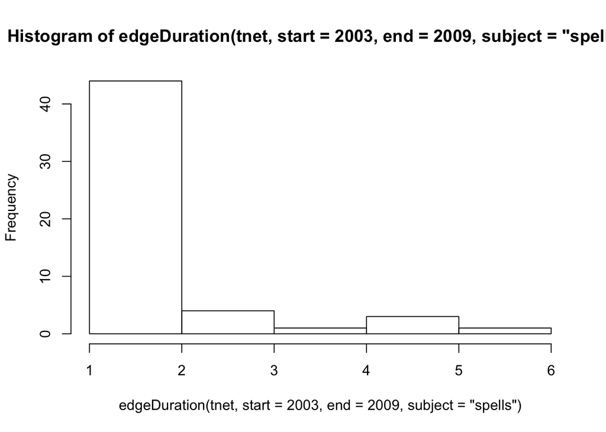

```r
hist(edgeDuration(tnet,start=2003,end=2009, subject='spells'))
```

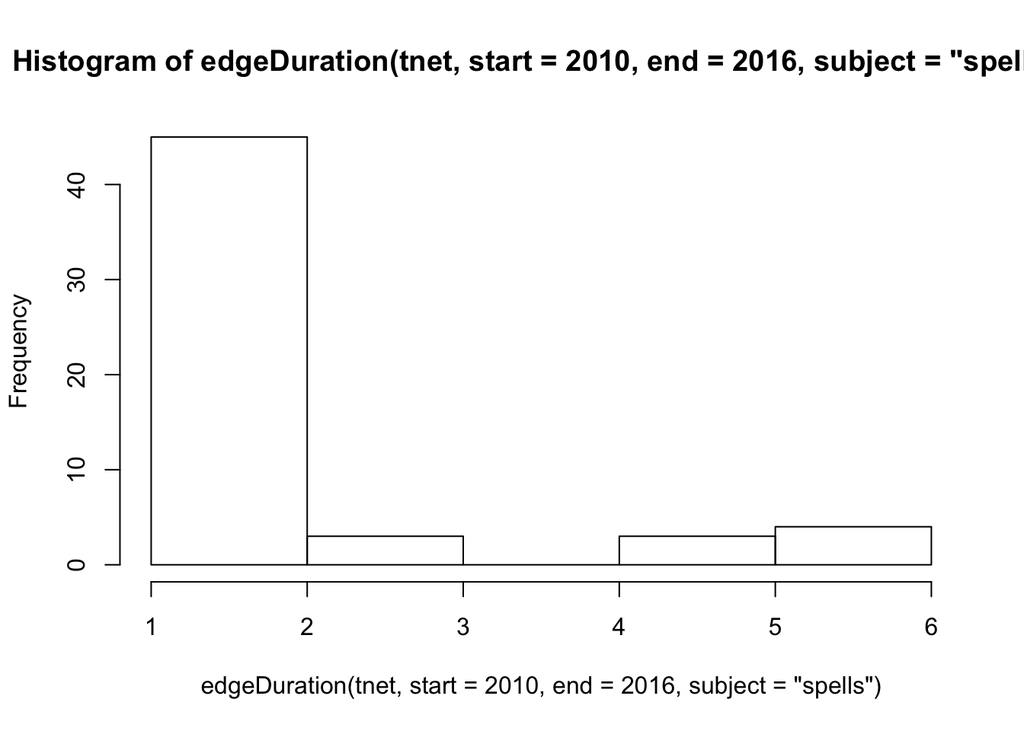

```r
hist(edgeDuration(tnet,start=2010,end=2016, subject='spells'))
```

## Most active interdepartmental co-authors

```r
vertexDuration(tnet)
```

```
##  [1] 15 15 15 15 15 15 15 15 15 15 15 15 15 15 15 15 15 15 15 15
```

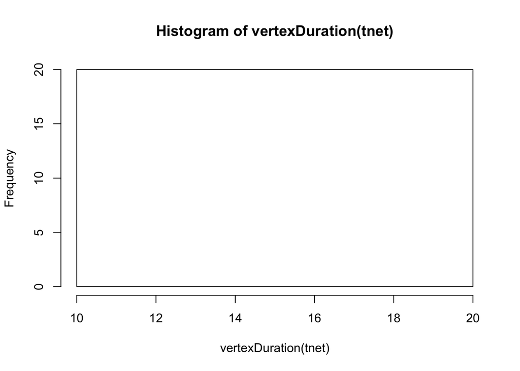

```r
hist(vertexDuration(tnet))
```

## Collapsing the dynamic (temporal) network

```r
aggnet = network.collapse(tnet, rm.time.info=F, rule='latest')
slice.par<-list(start=2002,end=2016,interval=15,
                aggregate.dur=15,rule='latest')
compute.animation(tnet,animation.mode='MDSJ',
                  slice.par=slice.par)
```

```
## Calculating layout for network slice from time  2002 to 2017
```

```
## The MDSJ Java library does not appear to be installed. The ndtv package can use MDSJ to provide a fast accurate layout algorithm. It can be downloaded from http://algo.uni-konstanz.de/software/mdsj/
```

[output not shown]

```
## The MDSJ library was not installed.
```

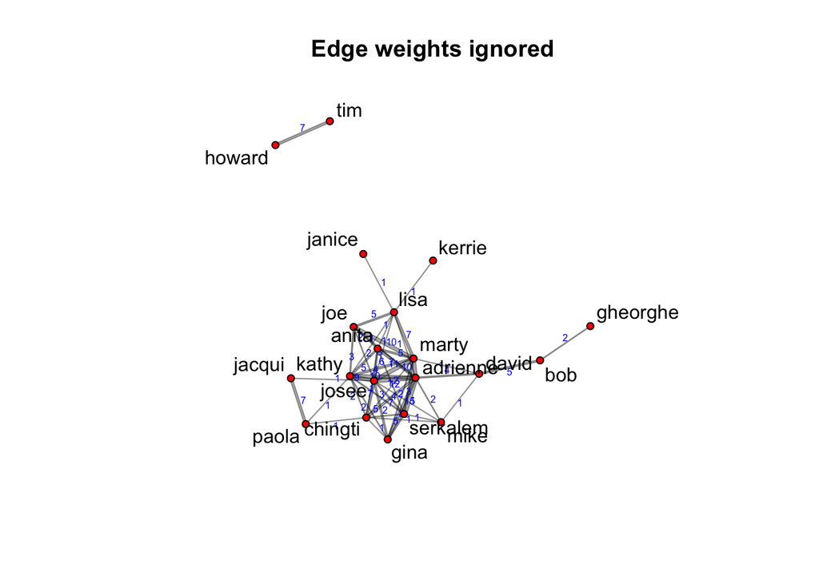

```r
# extract the coords so we can do a static plot
coords<-cbind(get.vertex.attribute.active(tnet,
                                          'animation.x',at=2002),
              get.vertex.attribute.active(tnet,
                                          'animation.y',at=2002))
plot(aggnet,coord=coords,
     edge.lwd='activity.duration', edge.col='#00000055',
     edge.label='activity.duration',edge.label.col='blue',
     edge.label.cex=0.5,main='Edge weights ignored', displaylabels=T)
```